# Concentration dynamics of a pollutant in a fluid with fuzzy propagation velocity by Zadeh’s Extension Principle

Matheus Saraiva Alcino, Silvio Antônio Bueno Salgado, Danilo Machado Pires, Sérgio Martins de Souza, Robson André Armindo, Nilton César da Silva

## The C++ algorithm

The algorithm was written in C++ language using standard libraries.

```cpp
#include <iostream>
#include <fstream>
#include <cmath>
#include <iomanip>
#include <stdio.h>
#include <vector>
#include <algorithm>
```

In this study the main idea is to allow the Zadeh extension principle to be applied to the expression (12) related to the pollutant concentration along the pipe.

$u(x,t)=f(x-ct)=\frac{1}{2\sqrt{\pi}}e^{-\frac{1}{4}(x-ct)^2}$

Assuming $c$ as a triangular fuzzy number that models the pollutant propagation velocity such that

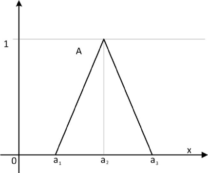

where $[a_1,a_2,a_3]$ is the inf, pic and sup values, i.e., the smallest, the avarage (maximum membership) and the largest values of $c$ respectively.

Since $[c]^{\alpha}=[c_{-}^{\alpha}; c_{+}^{\alpha}]$ $\forall~ \alpha \in [0,1]$ we have $[u(x,t)]^\alpha=[min f(s), max f(s)]$ where $s \in [x-c_{-}^{\alpha}t,x-c_{+}^{\alpha}t]$.

In summary the algorithm consists of the following steps

- It was defined a data structure able to memorize 3 double values type, which correspond to $x$, $u(x,t)$ e $\mu(c)$.

```cpp
using namespace std;
struct trinca{
       long double valorx, valorfx, valorp;
};
```

A variable of that type will be used to memorize values related in the matrix form, for exemple

| $x=30$ | $u(x=30,t=10)$ | $\mu(c)$ |
| --- | --- | --- |
| 30 | 0.000000000000000 | 0.0 |
| 30 | 0.000000000000000 | 0.1 |
| … | … | … |
| 30 | 0.000000000000007 | 0.4 |
| 30 | 0.000000000000021 | 0.5 |
| 30 | 0.000000000000061 | 0.6 |
| … | … | … |
| 30 | 0.000000000003918 | 1 |
| … | … | … |
| 30 | 0.000000000182274 | 0.6 |
| 30 | 0.000000000452826 | 0.5 |
| 30 | 0.000000001102691 | 0.4 |
| … | … | … |
| 30 | 0.000000014122280 | 0.1 |
| 30 | 0.000000031745587 | 0.0 |

It is important to notice that even when $x$ and $t$ are constants we have differents values of $u(x,t)$, because the velocity $c$ is still varying. Furthermore, the different merberships atributed to the distinct values of $c$ are the ones wich wil be extended to $u(x,t)$.

Three support functions were generated to the extension principle process:

- The sorting function: consists in to taking the values of matrix (array) generated in each point (exemple above) according to $u(x,t)$

```cpp
void ordenacao(vector < trinca > &vet)
{

    double b,i;
           trinca orden;

        b=1;
         while (b<vet.size())
        {
               orden.valorx = vet[b].valorx;
               orden.valorfx =vet[b].valorfx;
                 orden.valorp = vet[b].valorp;

           i = (b-1);
          while((i>=0)&&(vet[i].valorfx > orden.valorfx))
         {
             vet[i+1] = vet[i];
                    i = (i - 1);
        }
            vet[i+1]=orden;
        b+=1;
            }


}
```

- Since the data is already sorted a function called exentension principle is executed. This function verifies if it exists repeated values of $u(x,t)$ and deletes the one that presents the smallest merbership.

```cpp
void principioextencao(vector<trinca> &vet)
{
     int i,j;

     j=1;

     while(j<vet.size())
    {
       i = (j-1);
           if((vet[j].valorfx)==(vet[i].valorfx))
         {
                    if(vet[j].valorp>=vet[i].valorp)
                     {

                        vet.erase(vet.begin()+i);
                     }
                     else
                             {

                         vet.erase(vet.begin()+j);

                      }
            continue;
         }j+=1;

    }

 }
```

- Finally, there is the center of gravity function, which consists of the fuzzy set defuzzification step.

```cpp
long double centroide (vector<trinca> &veto)
{
     long double numerador,denominador,c;
     numerador=0.0;
     denominador=0.0;
      c=0.0;
 while(c<=(veto.size()))

    {
          numerador+=(veto[c].valorp)*(veto[c].valorfx);
          denominador+=veto[c].valorp;
     c+=1.0; }

   return (numerador/denominador);

}
```

Because of some particularities of the C language, some “holes” arises after the execution of the “principioextencao” function in some extreme points of the fuzzy $u(x,t)$ graph. We usually denominate that problem as noises, and this is adjusted by removing those points wich cause such noises. For example

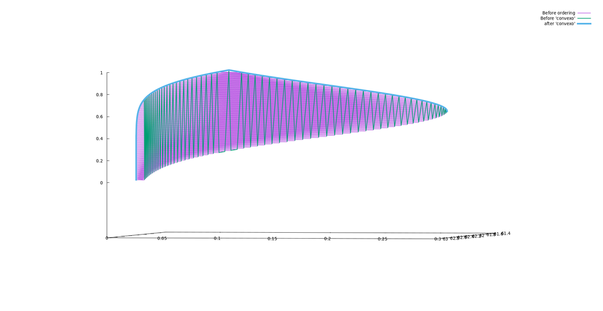

```cpp
void convexo(vector<trinca> &vet)
{        double i,j,l;
    j,l=1;

         while (l<(vet.size()-1.0))
           {
             i=j-1; l=j+1;
             if( (vet[i].valorp>=vet[j].valorp)&&(vet[j].valorp<=vet[l].valorp))
                    {       vet.erase(vet.begin()+j);

                    j=1;
              l=1;
                      continue;

                    }

          j+=1;
        }

}
```

- aposalgoritmo.gnu: contains the fuzzy set resulting from the extension principle, $x$, $u(x,t)$ e $\mu(u(x,t))$.
- sclassica.gnu : contains the values of $t$, $x$ e $u(x,t)$, from the classic function.
- classica.gnu : contains the values of $x$ e $u(x,t)$, from the classic function.
- defu.gnu : contains the deffuzificated values of $\mu(u(x,t))$ for each point of $x$.

```cpp
ofstream convex("./aposalgoritmo.gnu", ios::out);
ofstream borrao("./sclassica.gnu", ios::out);
ofstream cla("./classica.gnu", ios::out);
ofstream defuzzy("./defu.gnu", ios::out);
```

```cpp
int main()
{

  vector < trinca > vetorPonto;
  trinca armazena0,armazena1,armazena2;

 long double  pon,c,inf, sup, z,r,t,x,x1,u1,u2,u0,al,pic;
const  double d= 1;

// The parameters a1,a2 and a3 for the fuzzy number c
cout<<" Enter the lower range, the peak and the upper range of the triangular membership: "<<endl;
cin>>inf; cin>>pic; cin>>sup;
// The moment
cout<<" Enter time: "<<endl;
cin>>t;
// pipe length
cout<<"  Enter the lower and the upper limit of the pipe: "<<endl;
cin>>x; cin>>x1;


            // Initial point in the pipe.
        while(x<=x1)
        {
          al=0;
          while (al<=0.99)  //  Length of the whole, in this case (<80)
                  {
//[min f(s)]
              u1= (1/sqrt(4*d*M_PI))*exp((-0.25/d)*(x-((pic-inf)*al+inf)*t)*(x-((pic-inf)*al+inf)*t));
                    armazena1.valorx = x;
                            armazena1.valorfx =u1;
                            armazena1.valorp = al;
                            vetorPonto.push_back(armazena1);
//[max f(s)]
                            u2= (1/sqrt(4*d*M_PI))*exp((-0.25/d )*(x-((pic-sup)*al+sup)*t)*(x-((pic-sup)*al+sup)*t));
                            armazena2.valorx = x;
                            armazena2.valorfx =u2;
                            armazena2.valorp = al;
                            vetorPonto.push_back(armazena2);

                        al+=0.01;

              }

//  u(x,t) classic, membership equal to 1
          z=(1/sqrt(d*4*M_PI))*exp((-0.25/d)*(x-pic*t)*(x-pic*t));
          armazena0.valorx = x;
          armazena0.valorfx = z ;
            armazena0.valorp = 1;
          vetorPonto.push_back(armazena0);

// Stores classic function data (3d)  t, x , u(x,t)
                    borrao<<setiosflags(ios::fixed| ios:: showpoint)<<setprecision(15.0);
          borrao<<t<<" "<<x<<" "<<z<<endl;

// Stores classic function data (2d) x e u(x,t)
          cla<<setiosflags(ios::fixed| ios:: showpoint)<<setprecision(15.0);
          cla<<x<<" "<<z<<endl;

// Sorts data according to u(x,t)
          ordenacao(vetorPonto);

// More relevance
          principioextencao(vetorPonto);

//  Defuzzification
                    r=centroide(vetorPonto);

// Stores defuzzified data
          defuzzy<<setiosflags(ios::fixed| ios:: showpoint)<<setprecision(15.0);
          defuzzy<<x<<" "<<r<<endl;

// Eliminates "noise"
            convexo(vetorPonto);

 // Storage of fuzzy u(x,t)
          convex<<setiosflags(ios::fixed| ios:: showpoint)<<setprecision(15);

            for (int v=0;v<vetorPonto.size();v++)
               {
               convex<<vetorPonto[v].valorx<<" "<<vetorPonto[v].valorfx<<" "<<vetorPonto[v].valorp<<endl;
             }
                  convex<<" "<<endl;


          vetorPonto.clear();

              x+=0.01;

         }


 return 0;
}
```

The graphics used in the article were created using the software [**Gnuplot**](http://www.gnuplot.info/) .

This C++ code can be found at ( [**Code**](https://github.com/danilomachadopires/FuzzyASOC) ).

# Test suggestions

After compiling and executing the file FuzzyASOC.cpp testing differents values of $c=(a_1,a_2,a_3)$ and differents values of $t$.

| $t$ | $c=(a_1,a_2,a_3)$ |
| --- | --- |
| $t=30$ | $c=(1.8;2;2.2)$ |
| $t=30$ | $c=(1.8;2;2)$ |
| $t=30$ | $c=(2;2;2.2)$ |
| $t=10$ | $c=(1.9;2;2.1)$ |
| $t=50$ | $c=(1.9;2;2.1)$ |
| $t=100$ | $c=(1.9;2;2.1)$ |
| $t=400$ | $c=(1.9;2;2.1)$ |
| $t=800$ | $c=(1.9;2;2.1)$ |
| $t=1000$ | $c=(1.9;2;2.1)$ |
| $...$ | $...$ |

## Example

```cpp
$ g++ FuzzyASOC.cpp -o FuzzyASOC.exe
$ ./FuzzyASOC.exe
$ Enter the lower range, the peak and the upper range of the triangular membership:
1.8
2
2.2
>>Enter time?
30
>> Enter the lower and the upper limit of the pipe:
40
80
```

- GNUplot code (1)

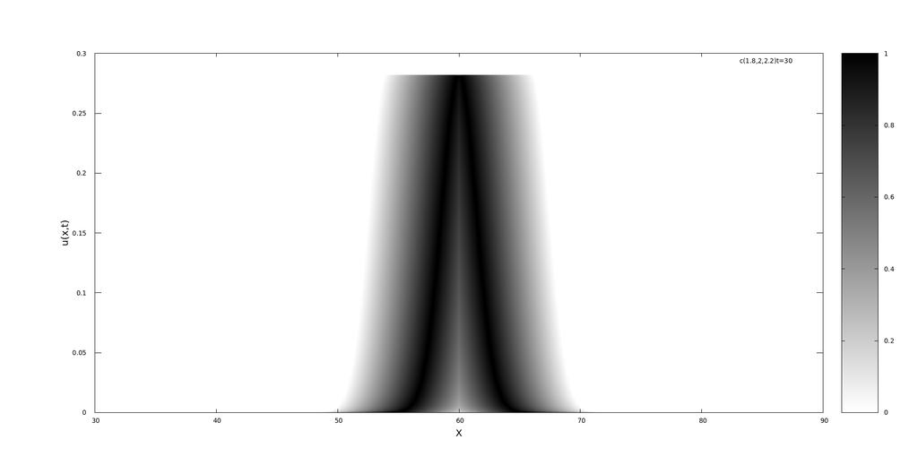

```cpp
gnuplot> set pm3d map
gnuplot> set palette defined (0 "white",1 "black")
gnuplot> set xlabel "X" font "Times-Roman,15"
gnuplot> set ylabel "u(x,t)" font "Times-Roman,15"
gnuplot> splot 'aposalgoritmo.gnu' with pm3d t"c(1.8,2,2.2) T=30"
```

- GNUplot code (2)

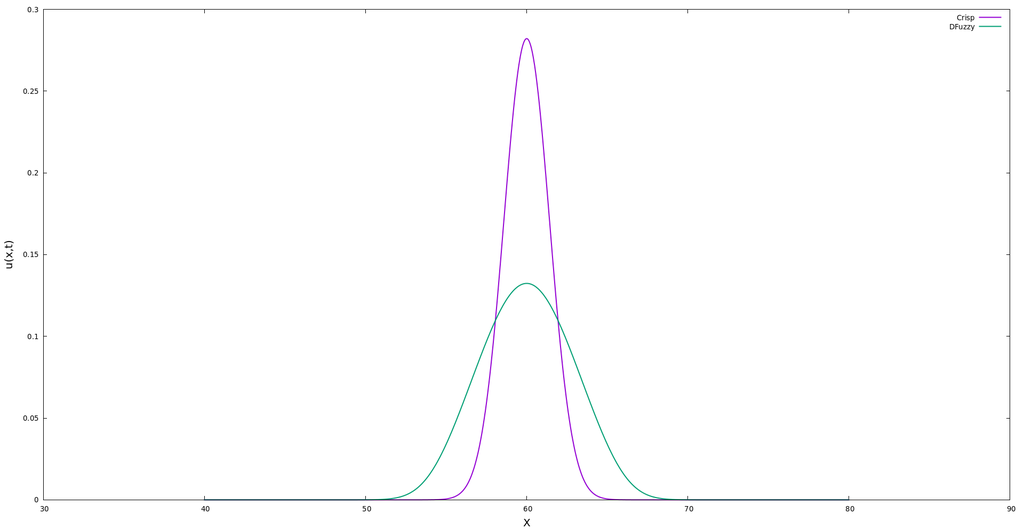

```cpp
gnuplot> plot 'classica.gnu' with l t"crisp", 'defu.gnu' with l t"DFuzzy"
gnuplot > reset
```

**Home page**